# Homework5

Bilal Shakir

2018-02-18

I start off by loading in the necessary data packages.

```r
## clearing out the global environment is a good idea before starting out

remove(list=ls())

## loading in the required datasets

pacman::p_load(tidyr, tidyverse,
               ggplot2, ggthemes,
               dplyr, RColorBrewer,
               gridExtra,
               texreg, readr,
               foreign, readstata13,
               interplot, stargazer,
               Zelig, broom,
               car, purrr,
               MASS, arm,
               pander, knitr,
               psych, cowplot,
               margins, scales,
               pastecs, plm,
               survival, ggplot2,
               ggrepel, pscl,
               GGally, foreign,
               RTextTools, feather,
               lfe, dplyr,
               corrplot, haven,
               rdrobust)

## loading in the required data

rdrobust_senate <- read_dta("Assignment5/Stata/rdrobust_senate.dta")

senate_data <- rdrobust_senate

### Load data base

data("rdrobust_RDsenate")
vote <- rdrobust_RDsenate$vote
margin <- rdrobust_RDsenate$margin

### Summary stats
summary(vote)
```

```
##    Min. 1st Qu.  Median    Mean 3rd Qu.    Max.    NA's
##    0.00   42.67   50.55   52.67   61.35  100.00      93
```

```r
summary(margin)
```

```
##     Min.  1st Qu.   Median     Mean  3rd Qu.     Max.
## -100.000  -12.206    2.166    7.171   22.766  100.000
```

This assignment is based on replicating the empirical illustration of the rdrobust package released by Calonico, Cattaneo and Titiunik (2015, hereafter CCT). In the analysis that follows, first, I replicate the results of CCT. Second, I discuss and offer a critical appraisal of these results, with the goal of attempting to underline some key features of Regression Discontinuity Analysis.

The rdrobust package, broadly speaking, constructs two types of RD plots: i) RD plots tracing the underlying regression function or ii) RD plots with binned sample means mimicking the underlying variability of the data. For more technical and methodological details please refer to Calonico, Cattaneo and Titiunik (2015a). In other words, the purpose behind one of the RD plots is to show that it fits the regression line well, whereas, the other RD plot is attempting to underline the variability of the data.

The basic principle of an RD design is fairly intuitive. For an RD design to work, you need three key features: 1) An outcome variable, 2) an assighment variable, 3) an “arbitray” rule or cut-off. Through such an “arbitrary cut-off” the RD design enables us to reproduce a randomized experiment. In the CCT case that is replicated below, our assignment variable is *margin* and our outcome variable is *vote*.

### *margin*

As highlighted by detailed description of CCT (2015), there are a total of 1297 observations in our data. The variable *margin* records the margin of victory in a given election for a U.S. Senate seat and is calculated by the difference between the vote share of the democratic party minus its strongest opponent. Given the largely two party structure of the U.S., the strongest opponent can, in most cases, be thought of as the Republican party’s vote share.

The outcome of the election is in favour of the Democratic party when the *margin* variable is above zero.

### *vote*

The variable *vote* ranges from 0 to 100 and records the outcome of the (two-periods ahead) election for that given seat. Thus, observations for years 2008 and 2010 have missing votes. The authors exploit the discontinuity in incumbency status that occurs at 0 on margin to employ an RD design. In addition, additional commands that are used include: rdrobust for point estimation and inference procedures, and rdbwselect for data-driven bandwidth selection.

Before proceeding with the RD analysis, it would be useful to just plot and visualize actual values from our data to get some intuition about what our data looks like.

[output not shown]

In the code chunk below, Figure 1 displays the RD plot with the default bin-select option (“esmv”) that estimates evenly spaced mimicking variance command. Following that, I also reproduce additional panels by varying the bin-select command. This helps us to visualize what is required for this regression. Note that we need to conduct an F-test to select the appropriate number of bins. While I have not done so below, this would have been a useful straetgy in selecting the appropriate number of bins by hand.

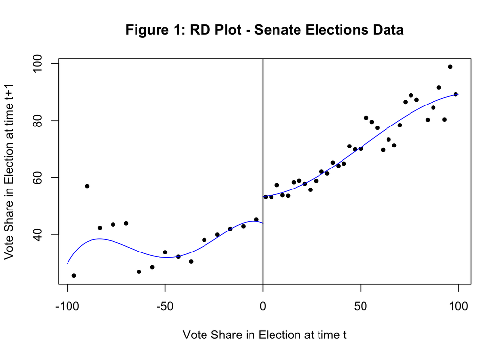

```r
### rdplot: default

rdp1 <- rdrobust::rdplot(y=rdrobust_RDsenate$vote,
                         x=rdrobust_RDsenate$margin,
                         title="Figure 1: RD Plot - Senate Elections Data",
            y.label="Vote Share in Election at time t+1",
            x.label="Vote Share in Election at time t"); rdp1
```

Call: rdplot

Number of Obs. 1297 Kernel Uniform

Number of Obs. 595 702 Eff. Number of Obs. 595 702 Order poly. fit (p) 4 4 BW poly. fit (h) 100.000 100.000 Number of bins scale 1 1

```r
summary(rdp1)
```

Call: rdplot

Number of Obs. 1297 Kernel Uniform

Number of Obs. 595 702 Eff. Number of Obs. 595 702 Order poly. fit (p) 4 4 BW poly. fit (h) 100.000 100.000 Number of bins scale 1 1

Bins Selected 15 35 Average Bin Length 6.667 2.857 Median Bin Length 6.667 2.857

IMSE-optimal bins 8 9 Mimicking Variance bins 15 35

Relative to IMSE-optimal: Implied scale 1.875 3.889 WIMSE variance weight 0.132 0.017 WIMSE bias weight 0.868 0.983

Figure 1 notes: As Calonico et al (2015) note, Figure 1 is constructed using the default options in the command ‘rdplot’, which produces a RD plot with evenly-spaced bins selected to mimic the underlying variability of the data and is implemented using spacings estimators.

I play around with the following binselect options to better understand how a RD function works by learning from the differences in the visualization.

binselect:

es: IMSE-optimal evenly-spaced method using spacings estimators. espr: IMSE-optimal evenly-spaced method using polynomial regression. esmv: mimicking variance evenly-spaced method using spacings estimators. This is the default option. esmvpr: mimicking variance evenly-spaced method using polynomial regression. qs: IMSE-optimal quantile-spaced method using spacings estimators. qspr: IMSE-optimal quantile-spaced method using polynomial regression. qsmv: mimicking variance quantile-spaced method using spacings estimators. qsmvpr: mimicking variance quantile-spaced method using polynomial regression.

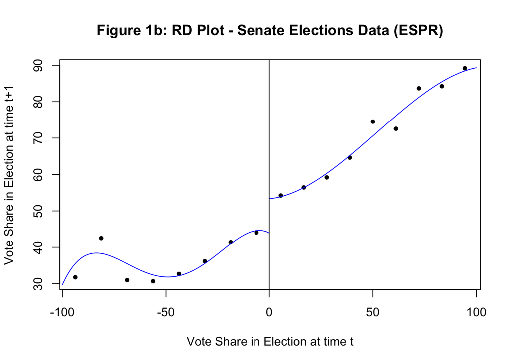

```r
## Evenly spaced estimators using evenly spaced method using polynomial regression (ESPR)

rdp1_1 <- rdplot(y=rdrobust_RDsenate$vote,
                 x=rdrobust_RDsenate$margin,
                 title="Figure 1b: RD Plot - Senate Elections Data (ESPR)",
            y.label="Vote Share in Election at time t+1",
            x.label="Vote Share in Election at time t",
            binselect = "espr"); rdp1_1
```

Call: rdplot

Number of Obs. 1297 Kernel Uniform

Number of Obs. 595 702 Eff. Number of Obs. 595 702 Order poly. fit (p) 4 4 BW poly. fit (h) 100.000 100.000 Number of bins scale 1 1

```r
summary(rdp1_1)
```

Call: rdplot

Number of Obs. 1297 Kernel Uniform

Number of Obs. 595 702 Eff. Number of Obs. 595 702 Order poly. fit (p) 4 4 BW poly. fit (h) 100.000 100.000 Number of bins scale 1 1

Bins Selected 8 9 Average Bin Length 12.500 11.111 Median Bin Length 12.500 11.111

IMSE-optimal bins 8 9 Mimicking Variance bins 21 36

Relative to IMSE-optimal: Implied scale 1.000 1.000 WIMSE variance weight 0.500 0.500 WIMSE bias weight 0.500 0.500

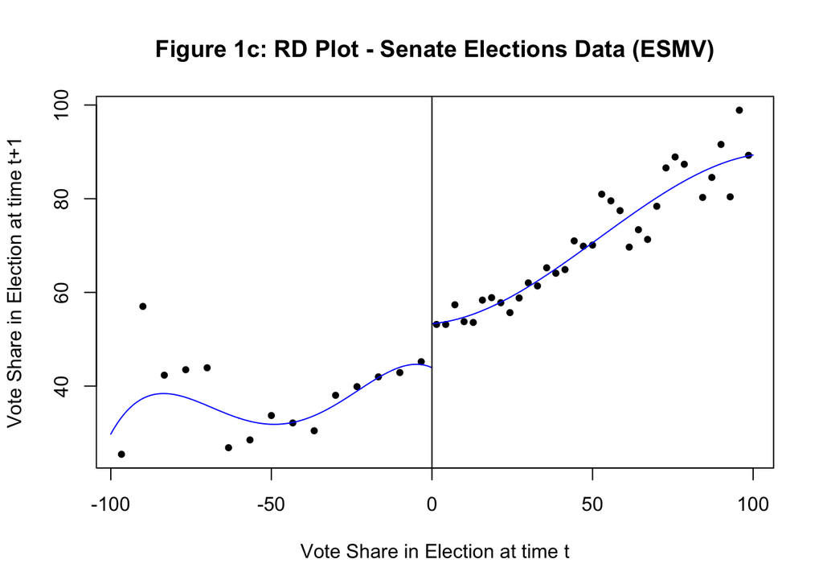

```r
## Evenly spaced estimators using evenly spaced method using polynomial regression (ESMV)

rdp1_2 <- rdplot(y=rdrobust_RDsenate$vote,
                 x=rdrobust_RDsenate$margin,
                 title="Figure 1c: RD Plot - Senate Elections Data (ESMV)",
            y.label="Vote Share in Election at time t+1",
            x.label="Vote Share in Election at time t",
            binselect = "esmv"); rdp1_2
```

Call: rdplot

Number of Obs. 1297 Kernel Uniform

Number of Obs. 595 702 Eff. Number of Obs. 595 702 Order poly. fit (p) 4 4 BW poly. fit (h) 100.000 100.000 Number of bins scale 1 1

```r
summary(rdp1_2)
```

Call: rdplot

Number of Obs. 1297 Kernel Uniform

Number of Obs. 595 702 Eff. Number of Obs. 595 702 Order poly. fit (p) 4 4 BW poly. fit (h) 100.000 100.000 Number of bins scale 1 1

Bins Selected 15 35 Average Bin Length 6.667 2.857 Median Bin Length 6.667 2.857

IMSE-optimal bins 8 9 Mimicking Variance bins 15 35

Relative to IMSE-optimal: Implied scale 1.875 3.889 WIMSE variance weight 0.132 0.017 WIMSE bias weight 0.868 0.983

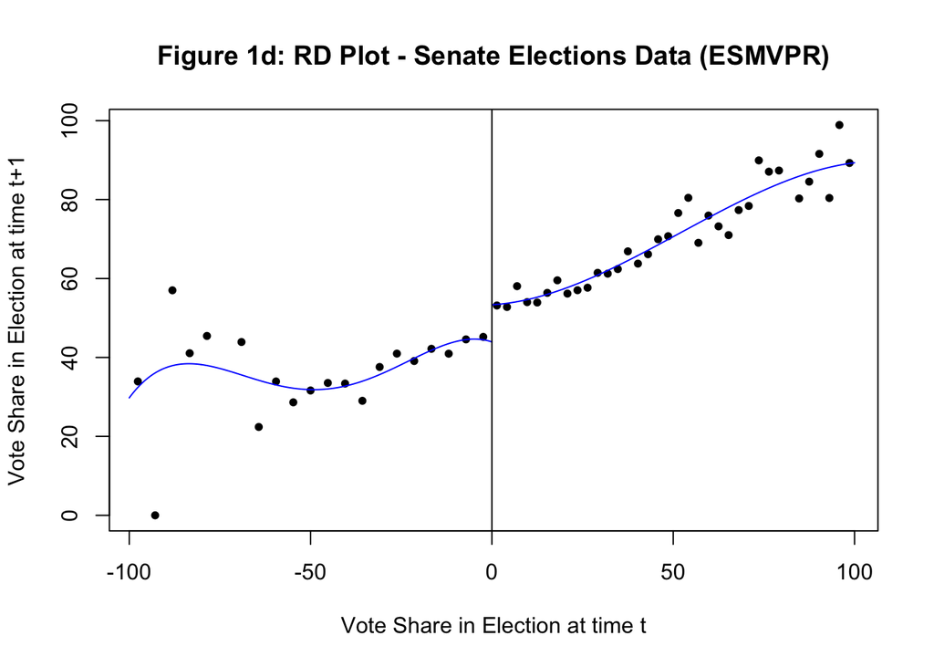

```r
## Evenly spaced estimators using evenly spaced method using polynomial regression (ESMVPR)

rdp1_3 <- rdplot(y=rdrobust_RDsenate$vote,
                 x=rdrobust_RDsenate$margin,
                 title="Figure 1d: RD Plot - Senate Elections Data (ESMVPR)",
            y.label="Vote Share in Election at time t+1",
            x.label="Vote Share in Election at time t",
            binselect = "esmvpr"); rdp1_3
```

Call: rdplot

Number of Obs. 1297 Kernel Uniform

Number of Obs. 595 702 Eff. Number of Obs. 595 702 Order poly. fit (p) 4 4 BW poly. fit (h) 100.000 100.000 Number of bins scale 1 1

```r
summary(rdp1_3)
```

Call: rdplot

Number of Obs. 1297 Kernel Uniform

Number of Obs. 595 702 Eff. Number of Obs. 595 702 Order poly. fit (p) 4 4 BW poly. fit (h) 100.000 100.000 Number of bins scale 1 1

Bins Selected 21 36 Average Bin Length 4.762 2.778 Median Bin Length 4.762 2.778

IMSE-optimal bins 8 9 Mimicking Variance bins 21 36

Relative to IMSE-optimal: Implied scale 2.625 4.000 WIMSE variance weight 0.052 0.015 WIMSE bias weight 0.948 0.985

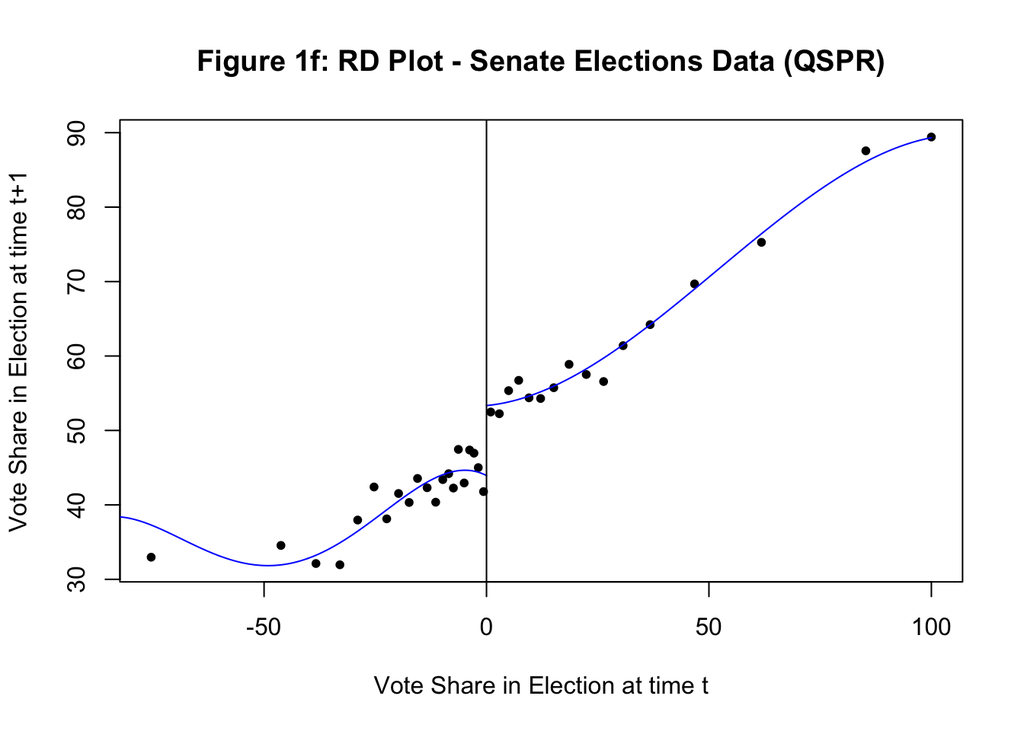

```r
## Evenly spaced estimators using evenly spaced method using polynomial regression (QSPR)

rdp1_4 <- rdplot(y=rdrobust_RDsenate$vote,
                 x=rdrobust_RDsenate$margin,
                 title="Figure 1f: RD Plot - Senate Elections Data (QSPR)",
            y.label="Vote Share in Election at time t+1",
            x.label="Vote Share in Election at time t",
            binselect = "qspr"); rdp1_4
```

Call: rdplot

Number of Obs. 1297 Kernel Uniform

Number of Obs. 595 702 Eff. Number of Obs. 595 702 Order poly. fit (p) 4 4 BW poly. fit (h) 100.000 100.000 Number of bins scale 1 1

```r
summary(rdp1_4)
```

Call: rdplot

Number of Obs. 1297 Kernel Uniform

Number of Obs. 595 702 Eff. Number of Obs. 595 702 Order poly. fit (p) 4 4 BW poly. fit (h) 100.000 100.000 Number of bins scale 1 1

Bins Selected 21 16 Average Bin Length 4.758 6.255 Median Bin Length 1.656 3.387

IMSE-optimal bins 21 16 Mimicking Variance bins 29 50

Relative to IMSE-optimal: Implied scale 1.000 1.000 WIMSE variance weight 0.500 0.500 WIMSE bias weight 0.500 0.500

[figure not shown]

```r
## Evenly spaced estimators using evenly spaced method using polynomial regression (QSMV)

rdp1_5 <- rdplot(y=rdrobust_RDsenate$vote,
                 x=rdrobust_RDsenate$margin,
                 title="Figure 1: RD Plot - Senate Elections Data (ESPR)",
            y.label="Vote Share in Election at time t+1",
            x.label="Vote Share in Election at time t",
            binselect = "qsmv"); rdp1_5
```

Call: rdplot

Number of Obs. 1297 Kernel Uniform

Number of Obs. 595 702 Eff. Number of Obs. 595 702 Order poly. fit (p) 4 4 BW poly. fit (h) 100.000 100.000 Number of bins scale 1 1

```r
summary(rdp1_5)
```

Call: rdplot

Number of Obs. 1297 Kernel Uniform

Number of Obs. 595 702 Eff. Number of Obs. 595 702 Order poly. fit (p) 4 4 BW poly. fit (h) 100.000 100.000 Number of bins scale 1 1

Bins Selected 28 49 Average Bin Length 3.569 2.042 Median Bin Length 1.393 1.139

IMSE-optimal bins 21 16 Mimicking Variance bins 28 49

Relative to IMSE-optimal: Implied scale 1.333 3.062 WIMSE variance weight 0.297 0.034 WIMSE bias weight 0.703 0.966

[figure not shown]

```r
## Evenly spaced estimators using evenly spaced method using polynomial regression (QSMVPR)

rdp1_6 <- rdplot(y=rdrobust_RDsenate$vote,
                 x=rdrobust_RDsenate$margin,
                 title="Figure 1: RD Plot - Senate Elections Data (ESPR)",
            y.label="Vote Share in Election at time t+1",
            x.label="Vote Share in Election at time t",
            binselect = "qsmvpr"); rdp1_6
```

Call: rdplot

Number of Obs. 1297 Kernel Uniform

Number of Obs. 595 702 Eff. Number of Obs. 595 702 Order poly. fit (p) 4 4 BW poly. fit (h) 100.000 100.000 Number of bins scale 1 1

```r
summary(rdp1_6)
```

Call: rdplot

Number of Obs. 1297 Kernel Uniform

Number of Obs. 595 702 Eff. Number of Obs. 595 702 Order poly. fit (p) 4 4 BW poly. fit (h) 100.000 100.000 Number of bins scale 1 1

Bins Selected 29 50 Average Bin Length 3.446 2.002 Median Bin Length 1.323 0.995

IMSE-optimal bins 21 16 Mimicking Variance bins 29 50

Relative to IMSE-optimal: Implied scale 1.381 3.125 WIMSE variance weight 0.275 0.032 WIMSE bias weight 0.725 0.968

##### Figure 2

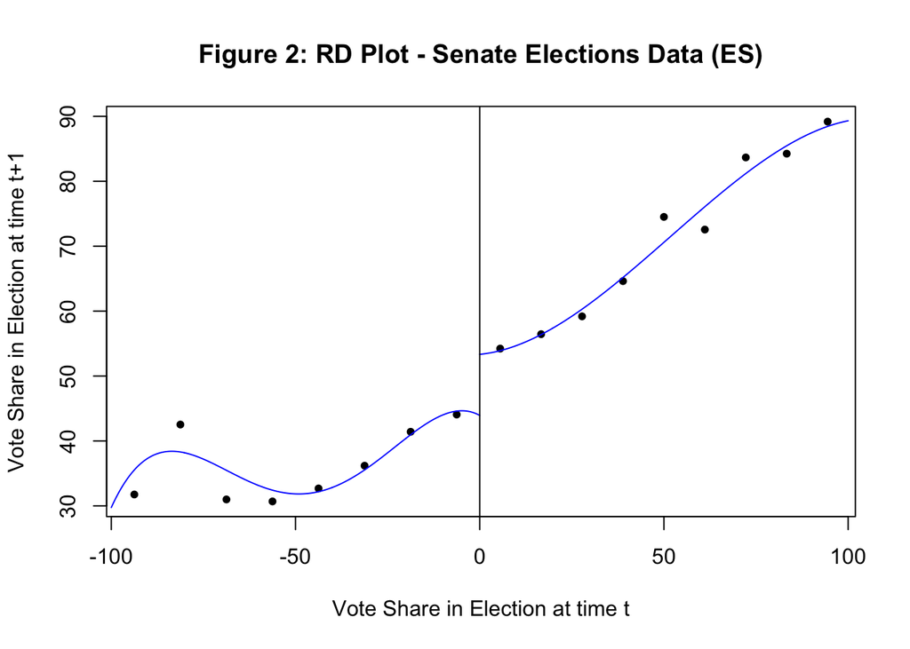

```r
### rdplot: (IMSE-optimal evenly-spaced bins)

rdp2 <- rdplot(y=vote,
               x=margin,
               binselect="es",
       title="Figure 2: RD Plot - Senate Elections Data (ES)",
       y.label="Vote Share in Election at time t+1",
       x.label="Vote Share in Election at time t"); rdp2
```

Call: rdplot

Number of Obs. 1297 Kernel Uniform

Number of Obs. 595 702 Eff. Number of Obs. 595 702 Order poly. fit (p) 4 4 BW poly. fit (h) 100.000 100.000 Number of bins scale 1 1

```r
summary(rdp2)
```

Call: rdplot

Number of Obs. 1297 Kernel Uniform

Number of Obs. 595 702 Eff. Number of Obs. 595 702 Order poly. fit (p) 4 4 BW poly. fit (h) 100.000 100.000 Number of bins scale 1 1

Bins Selected 8 9 Average Bin Length 12.500 11.111 Median Bin Length 12.500 11.111

IMSE-optimal bins 8 9 Mimicking Variance bins 15 35

Relative to IMSE-optimal: Implied scale 1.000 1.000 WIMSE variance weight 0.500 0.500 WIMSE bias weight 0.500 0.500

Figure 2 notes: Here, I re-construct an alternative RD plot using evenly-spaced bins selected to trace out the underlying regression function (i.e., using the IMSE-optimal selector) using the “es” model, also implemented using spacings estimators. The resulting plot is given in Figure 2 above.

While providing a good approximation to the underlying regression function (taking the global polynomial fit as benchmark), the IMSE-optimal number of bins will usually be too small in applications. As CCT (2015) note, this happens because the optimal formulas seek to balance squared bias and variance in order to approximate the underlying regression function globally.

It is important to underline that in order to better visualise our data or have a visual “cloud of points”, we need to increase the number of bins, that is, undersmooth the estimator. In other words, in order to increase the overall variability of the plotted points, we may reduce the bin-length by increasing the total number of bins used. This is achieved by altering the options scale as shown in the code chunk below.

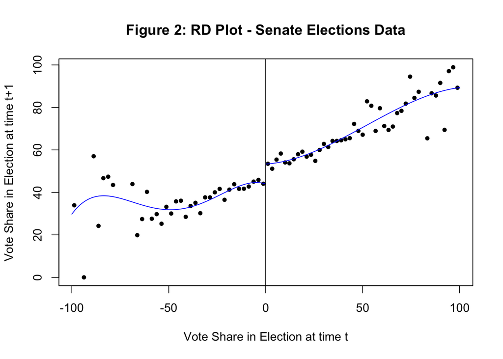

```r
### rdplot: scale=5 (evenly-spaced bins)

rdp3 <- rdplot(y=vote, x=margin, binselect="es", scale=5,
            title="Figure 2: RD Plot - Senate Elections Data",
            y.label="Vote Share in Election at time t+1",
            x.label="Vote Share in Election at time t"); rdp3
```

Call: rdplot

Number of Obs. 1297 Kernel Uniform

Number of Obs. 595 702 Eff. Number of Obs. 595 702 Order poly. fit (p) 4 4 BW poly. fit (h) 100.000 100.000 Number of bins scale 5 5

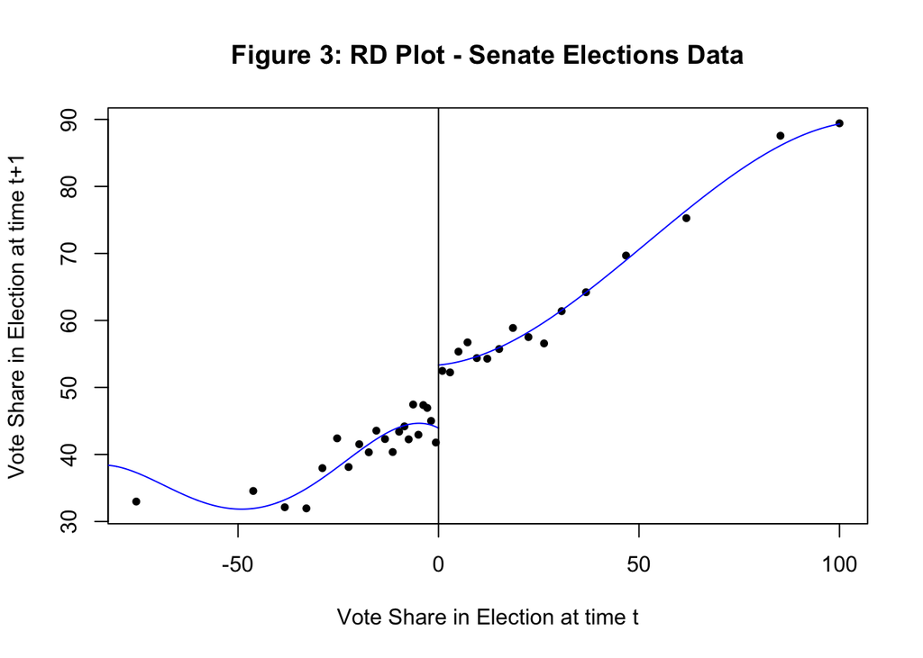

```r
### rdplot: quantile-spaced bins (data-driven automatic option)

rdp4 <- rdplot(y=vote, x=margin, binselect="qs",
            title="Figure 3: RD Plot - Senate Elections Data",
            y.label="Vote Share in Election at time t+1",
            x.label="Vote Share in Election at time t")
```

```r
rdp4
```

Call: rdplot

Number of Obs. 1297 Kernel Uniform

Number of Obs. 595 702 Eff. Number of Obs. 595 702 Order poly. fit (p) 4 4 BW poly. fit (h) 100.000 100.000 Number of bins scale 1 1

Going for the ‘all true’ option

```r
rdrobust(y = vote, x = margin, all = TRUE)
```

```
## Call: rdrobust
##
## Number of Obs.                 1297
## BW type                       mserd
## Kernel                   Triangular
## VCE method                       NN
##
## Number of Obs.                 595         702
## Eff. Number of Obs.            359         322
## Order est. (p)                   1           1
## Order bias  (p)                  2           2
## BW est. (h)                 17.708      17.708
## BW bias (b)                 27.984      27.984
## rho (h/b)                    0.633       0.633
```

```r
### rdrobust: default
rdrobust(y=vote, x=margin)
```

Call: rdrobust

Number of Obs. 1297 BW type mserd Kernel Triangular VCE method NN

Number of Obs. 595 702 Eff. Number of Obs. 359 322 Order est. (p) 1 1 Order bias (p) 2 2 BW est. (h) 17.708 17.708 BW bias (b) 27.984 27.984 rho (h/b) 0.633 0.633

```r
### rdrobust: all estimates option
rdrobust(y=vote, x=margin, all=TRUE)
```

Call: rdrobust

Number of Obs. 1297 BW type mserd Kernel Triangular VCE method NN

Number of Obs. 595 702 Eff. Number of Obs. 359 322 Order est. (p) 1 1 Order bias (p) 2 2 BW est. (h) 17.708 17.708 BW bias (b) 27.984 27.984 rho (h/b) 0.633 0.633

```r
### rdbwselect: all bandwidth options
rdbwselect_2014(y=vote, x=margin, all=TRUE)
```

Call: rdbwselect_2014(y = vote, x = margin, all = TRUE)

BW Selector All  
Number of Obs 1297  
NN Matches 3  
Kernel Type Triangular

```
               Left Right
```

Number of Obs 595 702  
Order Loc Poly (p) 1 1  
Order Bias (q) 2 2

```
       h        b
```

CCT 16.79357 27.43722 IK 15.66761 16.48524 CV 35.42113 NA

##### Challenges and Solutions with RD: Cross Validation

It would be useful to first start by giving an overview of the Cross Validation function. Note that while it is straightforward to estimate a linear or polynomial regression within a given window of bandwidth around the cut-off point, it is challenging to choose this bandwidth.

In general, choosing a bandwidth in nonparametric estimation involves finding an optimal balance between precision and bias: While using a larger bandwidth yields more precise estimates, since more data points are used in the regression, as demonstrated above, the linear specification is less likely to be accurate, which can lead to bias when estimating treatment effects. In other words, larger bandwith would lead to smaller confidence intervals but there is a greater change of bias.

Here, broadly speaking there are two procedures that have been used for choosing an optimal bandwidth for nonparametric regressions and have been used for RD designs. The first is a cross-validation procedure; the second “plugs-in” a “rule-of-thumb” bandwidth and parameter estimates from the data into an optimal bandwidth formula to get the desired bandwidth. Both procedures are based on the concept of mean square error (MSE), which measures the trade-off between bias and precision.

Note that as the bandwidth in an RD set up gets larger, the estimates are more precise, but the potential for bias is also larger. The Cross-Validation Procedure is a formal way of choosing this optimal bandwidth.

#### The Cross-Validation Procedure

The first formal way of choosing the optimal bandwidth, which is used widely in the literature, is called the “leave-one-out” cross-validation procedure. Recently, Ludwig and Miller (2005) and Imbens and Lemieux (2008) have proposed a version of the “leave-one-out” cross validation procedure that is tailored for the RD design. An objective function showcasing this procedure is outlined in the code chunk below this analysis.

Note that the process for this cross-validation procedure can be carried out as follows:

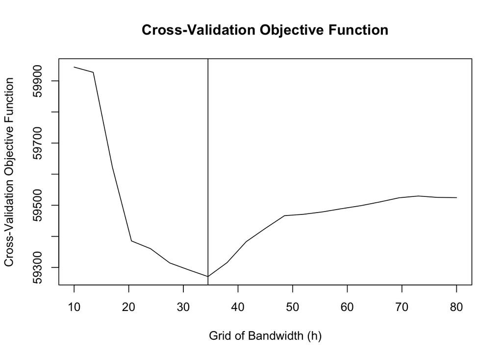

```
## Call:
## rdbwselect_2014(y = vote, x = margin, bwselect = "CV", cvgrid_min = 10,
##     cvgrid_max = 80, cvplot = TRUE)
##
## BW Selector   CV
## Number of Obs 1297
## NN Matches    3
## Kernel Type   Triangular
##
##                    Left Right
## Number of Obs      595  702
## Order Loc Poly (p) 1    1
## Order Bias (q)     2    2
##
##         h    b
## [1,] 34.5 34.5
```

```r
### rdbwselect: CV option with plot

rdbwselect_2014(y=vote, x=margin, bwselect="CV",
           cvgrid_min=10, cvgrid_max=80, cvplot=TRUE)
```

```r
### Other examples not reported in paper.
### rdrobust: using uniform kernel (instead of default, triangular kernel)
rdrobust(y=vote, x=margin, kernel="uniform")
```

Call: rdrobust

Number of Obs. 1297 BW type mserd Kernel Uniform VCE method NN

Number of Obs. 595 702 Eff. Number of Obs. 262 228 Order est. (p) 1 1 Order bias (p) 2 2 BW est. (h) 11.157 11.157 BW bias (b) 22.670 22.670 rho (h/b) 0.492 0.492

```r
### rdrobust: using IK bandwidth selection (instead of default, CCT)
rdrobust(y=vote, x=margin, bwselect="msetwo")
```

Call: rdrobust

Number of Obs. 1297 BW type msetwo Kernel Triangular VCE method NN

Number of Obs. 595 702 Eff. Number of Obs. 336 325 Order est. (p) 1 1 Order bias (p) 2 2 BW est. (h) 16.154 18.009 BW bias (b) 27.096 29.205 rho (h/b) 0.596 0.617

```r
### rdrobust: using CV bandwidth selection (instead of default, CCT)
rdrobust(y=vote, x=margin, bwselect="msecomb2")
```

Call: rdrobust

Number of Obs. 1297 BW type msecomb2 Kernel Triangular VCE method NN

Number of Obs. 595 702 Eff. Number of Obs. 359 325 Order est. (p) 1 1 Order bias (p) 2 2 BW est. (h) 17.708 18.009 BW bias (b) 27.984 29.205 rho (h/b) 0.633 0.617

```r
### rdrobust: using manual bandwidths (instead of default, data-driven automatic)
rdrobust(y=vote, x=margin, h=15, rho=0.8)
```

Call: rdrobust

Number of Obs. 1297 BW type Manual Kernel Triangular VCE method NN

Number of Obs. 595 702 Eff. Number of Obs. 319 288 Order est. (p) 1 1 Order bias (p) 2 2 BW est. (h) 15.000 15.000 BW bias (b) 18.750 18.750 rho (h/b) 0.800 0.800

```r
### rdrobust: using higher-order polynomials
### (instead of default, p=1 (local-linear) & q=2 (local-quadratic))
rdrobust(y=vote, x=margin, p=2, q=4)
```

Call: rdrobust

Number of Obs. 1297 BW type mserd Kernel Triangular VCE method NN

Number of Obs. 595 702 Eff. Number of Obs. 304 263 Order est. (p) 2 2 Order bias (p) 4 4 BW est. (h) 13.660 13.660 BW bias (b) 39.927 39.927 rho (h/b) 0.342 0.342

```r
### rdrobust: using residual plug-in standard errors
### (instead of nearest-neighbor residuals)
#rdrobust(y=vote, x=margin, vce="resid")

### rdrobust: sharp kink RD (first derivative of regression functions)
#rdrobust(y=vote, x=margin, deriv= "hc0")
```

###### Concluding Remarks

More importantly, as Bailey (2016) outlines, while Regression Discontinuity (RD) analysis is an extremely useful and powerful econometric tool, it is not without its pitfalls. Crucially, some issues include that if people can manipulate their score on the assignment variable, then the RD estimates no longer capture just the effect of the treatment. Moreover, it will additionally capture the effects of whatever qualities are overrepresented among the people who were able to boost their assignment score above the cut-off thresholds. One crucial diagnostic that can help us in identifying such a scenario is by showing a histogram of the observations that shows if there is a spike right after or before the treatment. This follows with the advice of Imbens and Lemiex (2008).

Bibliography:

Calonico, Sebastian, Matias D. Cattaneo, and Rocio Titiunik. “rdrobust: An r package for robust nonparametric inference in regression-discontinuity designs.” R Journal 7, no. 1 (2015): 38-51.

Calonico, Sebastian, Matias D. Cattaneo, and Rocio Titiunik. “Robust nonparametric confidence intervals for regression‐discontinuity designs.” Econometrica 82, no. 6 (2014): 2295-2326.

Jacob, R., Zhu, P., Somers, M.A. and Bloom, H., 2012. A Practical Guide to Regression Discontinuity. MDRC.